# Downstream Analysis Notebook

Dídac Jiménez

21-05-2023

## Purpose

The purpose of this notebook is to analyze the counts matrix obtained from single cell RNA sequencing raw data. The process involves quality control, scaling, dimensional reduction, clustering,differential expression analysis and a comparison with the same procedure on *ground truth* data. I used the Seurat package which provides all the tools needed for the analysis.

## Preparation and setup

### Set parameters and indicate paths

Indicate the preprocessing tool used, and a name for the project. The preporcessing tool name must be one of the provided after the #.

```r
# General variables
projectname<-"Prototype"
tool<-"SalmonAlevin"#  "KallistoBustools", "StarSolo", UmiTools or "SalmonAlevin"
```

Next chunk saves the path to the count matrix, the list of genes and the list of cells. *This is not provided in the github* so files need to be provided to reproduce results.

```r
# Dataset location
matrixpath<-"~/Work/TFM/Runs/SA_2505_78/output/alevin/quants_mat.gz"
featurespath<-NaN #Only for KB and StarSolo
cellspath<-NaN #Only for KB and StarSolo
```

Last chunk points to the variety of accessory files needed in the analysis. To reproduce the results *set the working directory to the repository* and the *knit directory to the working directory*, then, for `tabulaMuris_anotatedTable_path` and `clusterIdents_path` choose the anotatedTable.csv and idents.csv files of the same cell dataset.

```r
# Accessory files
MT_genespath<-"./Refs/MTgenes.csv"
rRNA<- "./Refs/rRNA.csv"
ensemblid2description_path<-"./Refs/ensemblid2description.csv"
tabulaMuris_anotatedTable_path<-"./Refs/10X_P7_8_anotatedTable.csv" # Make sure this file is obtained from the data of the same tissue
clusterIdents_path<-"./Refs/10X_P7_8_idents.csv"
```

### Load raw files into counts matrix

Outputs from each preprocessing tool are different. I will define and use different functions to generate a counts matrix.

```r
if (tool == "KallistoBustools" || tool == "StarSolo"){
  counts<-ReadMtx(
    mtx = matrixpath,
    cells = cellspath,
    features = featurespath,
    cell.column = 1,
    feature.column = 1,
    cell.sep = "\t",
    feature.sep = "\t",
    skip.cell = 0,
    skip.feature = 0,
    mtx.transpose = tool == "KallistoBustools",
    unique.features = TRUE,
    strip.suffix = FALSE
)
  # Ensembl version removal
  rownames(counts)<-sub('\\.[0-9]*$', '', rownames(counts))
}

if (tool == "SalmonAlevin"){
  txi <- tximport::tximport(matrixpath, type="alevin")
  counts<-txi$counts
  # Ensembl version removal
  rownames(counts)<- sub('\\.[0-9]*$', '', rownames(txi$counts))
}

if (tool == "UmiTools"){
  source("~/Work/TFM/Code/Pipelines/umitools_to_10x.R")
  umitools_to_mtx(matrixpath, output_path = sub("counts.tsv","",matrixpath))
  counts <- Read10X(sub("counts.tsv","",matrixpath),
                  gene.column = 1)
}
```

### Tag mitochondrial genes

Mitochondrial genes must have a tag on their name so that we can use the proportion of mitochondrial transcripts as a quality control measure. This is better done before the construction of the `Seurat` object. For this, I use a list of all mitochondrial genes in mouse previously acquired from biomart.

```r
#List of the names of our genes
gene_names<-data.frame(ens=rownames(counts))

# Lists generated Using Biomart from Ensembl to  create a list of ENS genes corresponding to mitochondrial genes
MT_genes<-data.frame(MT=read.csv(MT_genespath))
rRNA<-data.frame(rNA=read.csv(rRNA))

# Loop through all gene names and tag those found in the list
MT_count <-0

for (i in 1:length(gene_names$ens)){
  if (gene_names$ens[i] %in% MT_genes$ensembl_gene_id){
    MT_count<-MT_count+1 # To check if it works
    gene_names$ens[i] <- paste(c("MT-",gene_names$ens[i]),sep="",collapse = "")
  }
}

# Change names in the raw data
row.names(counts)<-gene_names$ens # Change row names of counts matrix
```

### Generate Seurat object

Finally I create the ‘Seurat’ object which we will use to proceed with the analysis. There is a small filtering involved in which we only include features detected in at least 5 cells, and only cells with at least 5 features.

```r
min.cells.features <- c(5,5) # CreateSeuratObject. Include features detected in at least this many cells, and cells with at least this many features
seurat.obj <- CreateSeuratObject(counts = counts,
                                 project = "projectname",
                                 min.cells = 5,
                                 min.features = 5)
```

## Quality Control

### Data exploration

The first step of the downstream analysis is the quality control, which consists in manually filtering cells above or under some threshholds. Before filtering, however, I check how many cells, genes and molecules are present in the dataset which are relevant metrics for preprocessing.

```r
sum(seurat.obj$nCount_RNA)
```

```
## [1] 7737860
```

```r
length(colnames(seurat.obj))
```

```
## [1] 111480
```

```r
length(rownames(seurat.obj))
```

```
## [1] 19657
```

This dataset obtained trough our SalmonAlevin pipeline has a total of 19657 genes expressed across 111480 cells, totalling 7.73786^{6} RNA molecules.

In the second step, I compute the percentage of mitochondrial transcripts for each cell, to use in the filtering.

```r
# We use the label we added earlier and add the percentage as a column in the metadata of each cell
seurat.obj[["percent.mt"]]<-PercentageFeatureSet(seurat.obj,pattern = "^MT-")
```

We then plot the three metadata values: Mitochondrial percentage, number of molecules and number of features. A good dataset should have linear relationship between number of features and number of molecules, though a plateau is fine. As for the violin plot, we will use it to set the limits for our filtering.

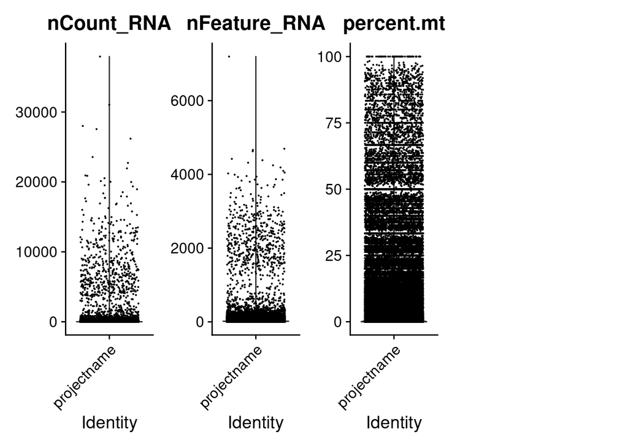

```r
VlnPlot(seurat.obj, features = c("nCount_RNA", "nFeature_RNA","percent.mt"), ncol = 5)
```

```
## Rasterizing points since number of points exceeds 100,000.
## To disable this behavior set `raster=FALSE`
```

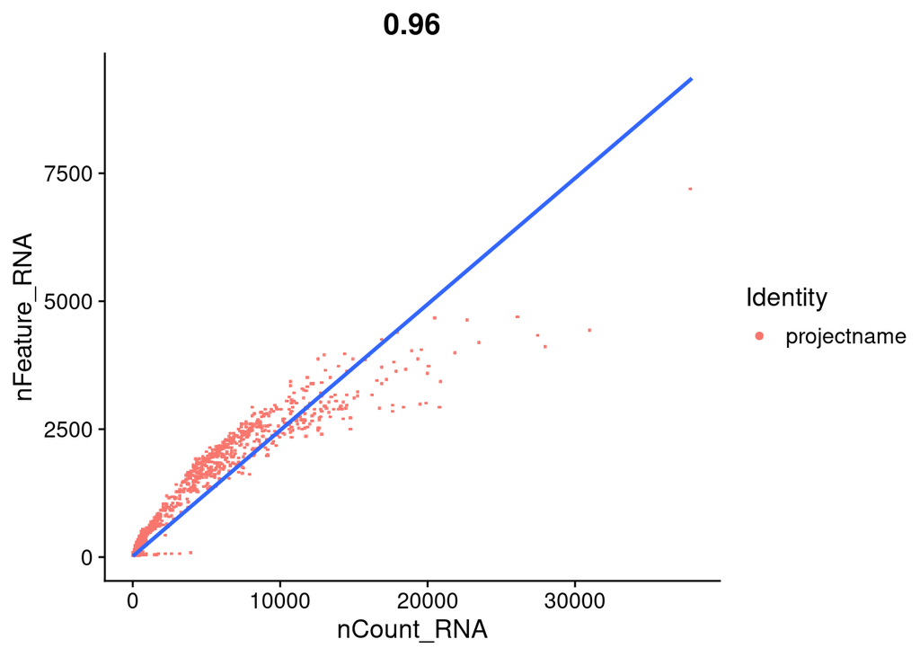

```r
FeatureScatter(seurat.obj, feature1 = "nCount_RNA", feature2 = "nFeature_RNA")+geom_smooth(method='lm')
```